# OZNAL projekt 3

# Histogramy

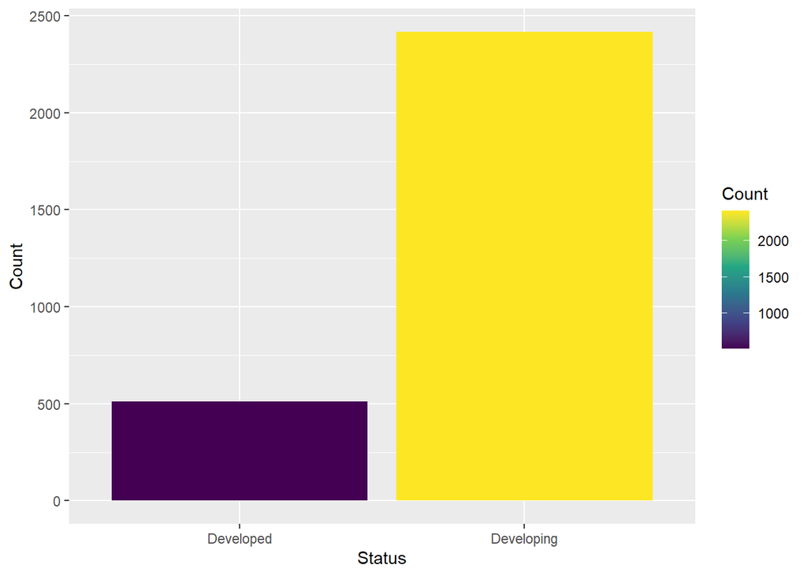

```r
# Histogram rozvojových a rozvinutých krajín
data %>%
  count(Status) %>%
  rename(Count = n) %>%
  ggplot(aes(x=Status, y=Count)) +
  geom_histogram(stat="identity", aes(fill=Count)) +
  scale_fill_viridis_c()
```

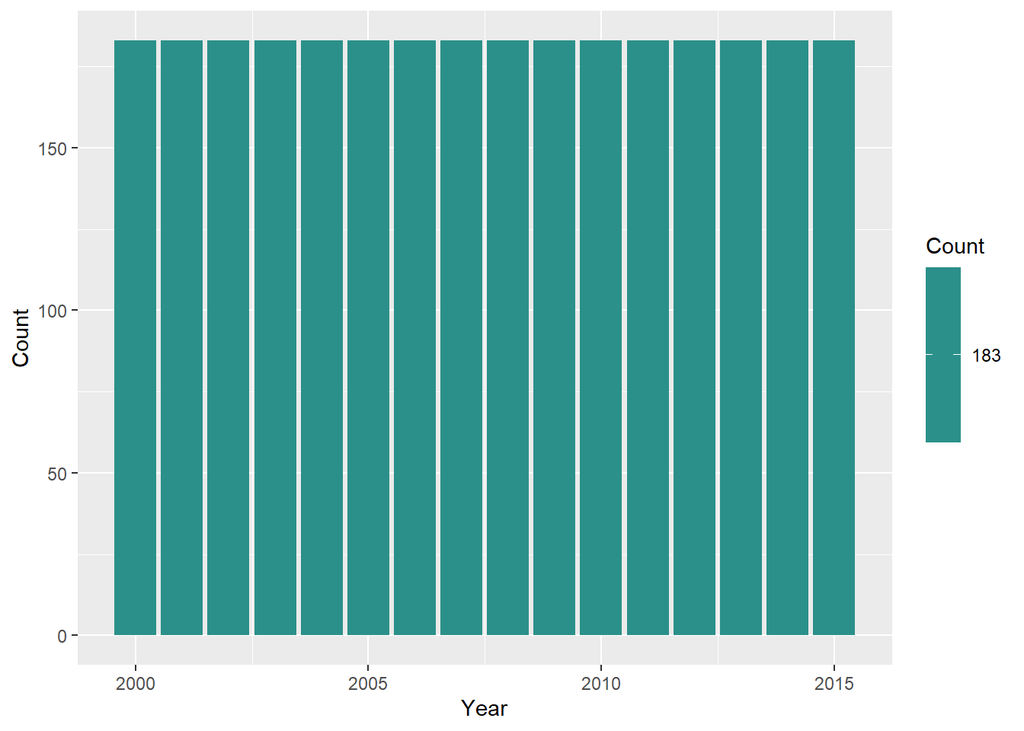

```r
# Histogram rokov, kedy boli robené merania
data %>%
  count(Year) %>%
  rename(Count = n) %>%
  ggplot(aes(x=Year, y=Count)) +
  geom_histogram(stat="identity", aes(fill=Count)) +
  scale_fill_viridis_c()
```

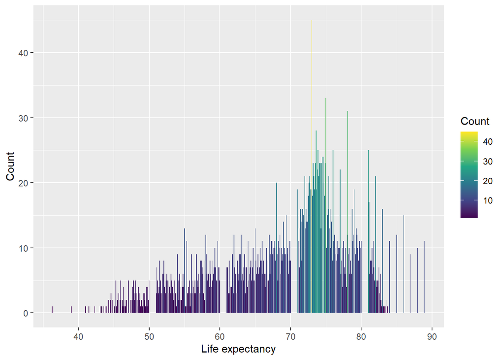

```r
# Histogram dĺžky života
data %>%
  count(`Life expectancy`) %>%
  rename(Count = n) %>%
  ggplot(aes(x=`Life expectancy`, y=Count)) +
  geom_histogram(stat="identity", aes(fill=Count)) +
  scale_fill_viridis_c()
```

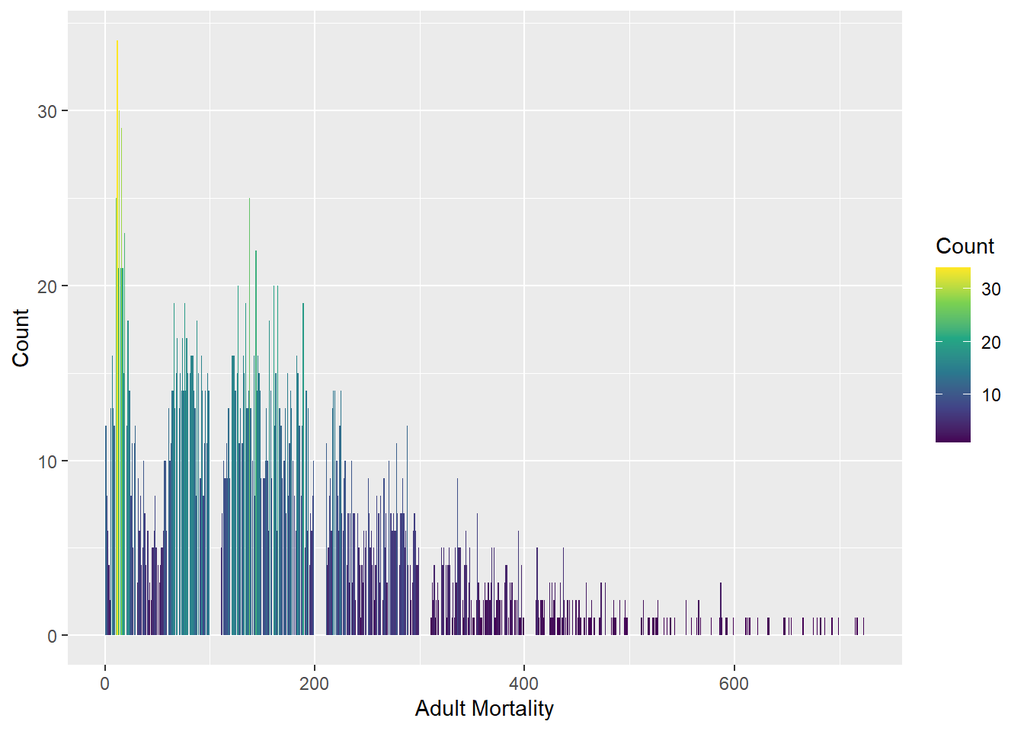

```r
# Histogram adult mortality
data %>%
  count(`Adult Mortality`) %>%
  rename(Count = n) %>%
  ggplot(aes(x=`Adult Mortality`, y=Count)) +
  geom_histogram(stat="identity", aes(fill=Count)) +
  scale_fill_viridis_c()
```

Pri zobrazení histogramov vidíme, že v datasete je **omnoho viac záznamov s rozvojových krajín ako z rozvinutých**. **Roky**, v ktorých boli robené merania, sú zastúpené **rovnomerne**. Pred odstránením predchádzajúcich 10 riadkov pre chýbajúce záznamy v Life expectancy sme mali v jeden rok viac záznamov. Ďalej vidíme rozdelenie dĺžky života a adult mortality.

# Zvyšné chýbajúce hodnoty

```
##                         Country                            Year
##                               0                               0
##                          Status                 Life expectancy
##                               0                               0
##                 Adult Mortality                   infant deaths
##                               0                               0
##                         Alcohol          percentage expenditure
##                             193                               0
##                     Hepatitis B                         Measles
##                             553                               0
##                             BMI               under-five deaths
##                              32                               0
##                           Polio               Total expenditure
##                              19                             226
##                      Diphtheria                        HIV/AIDS
##                              19                               0
##                             GDP                      Population
##                             443                             644
##            thinness  1-19 years              thinness 5-9 years
##                              32                              32
## Income composition of resources                       Schooling
##                             160                             160
```

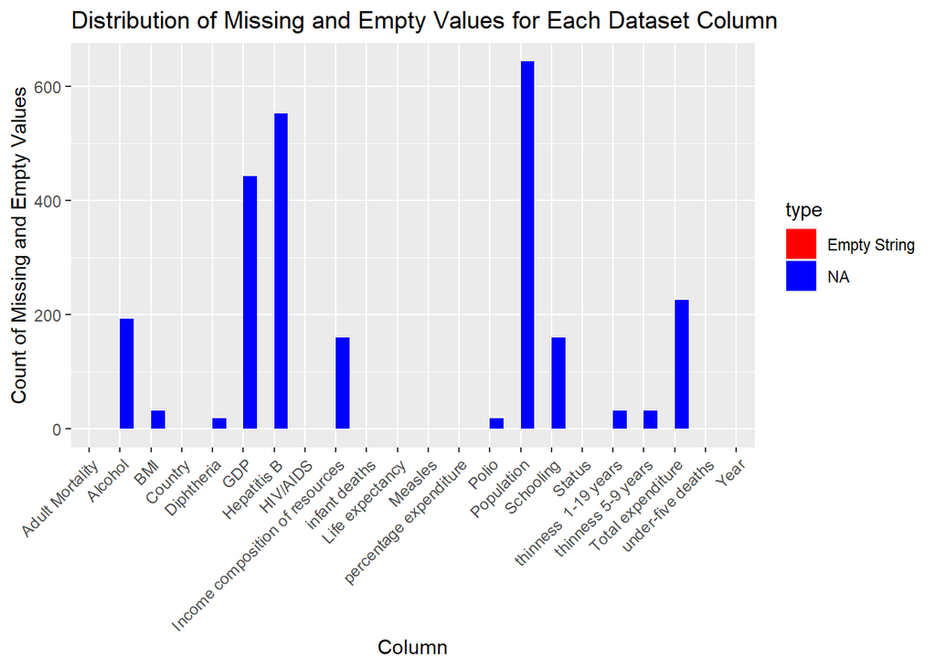

Kontrolovali sme aj ostatné chýbajúce hodnoty. Vidíme, že pomerne dosť sa ich nachádza aj v stĺpcoch **Population** a **hepatits B** alebo **GDB**. V ostaných je len menej, alebo žiadne.

Drop NA rows pre použité stĺpce v modeli, kvôli prevencii proti odstráneniu počas predikcii:

```r
library(conflicted)
data %<>%
  dplyr::select(Status, `Life expectancy`, `Adult Mortality`, Alcohol,
         `percentage expenditure`, BMI, `Total expenditure`,
         Diphtheria, `HIV/AIDS`, GDP, `Income composition of resources`,
         Schooling) %>%
  drop_na()
```

## Pairplot

- identifikácia vzťahov a vzorov medzi premennými

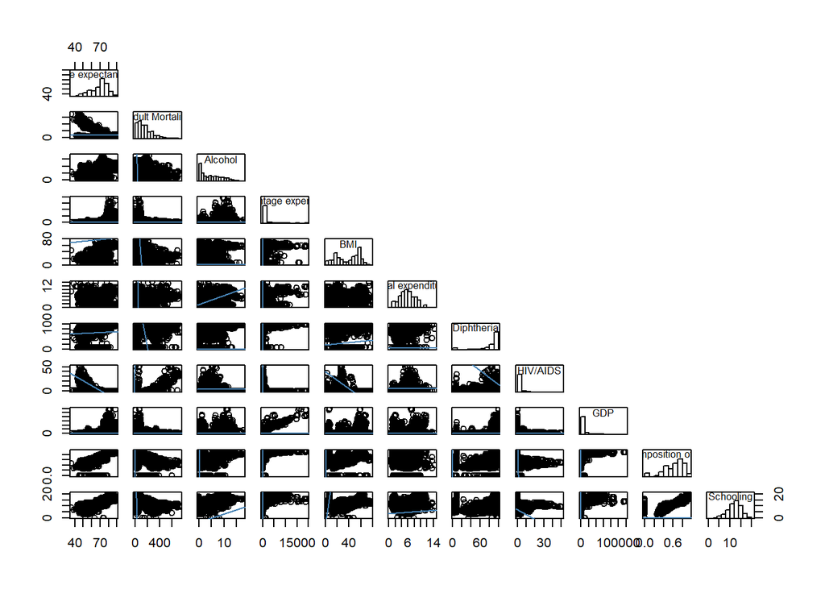

```r
#-----Helper functions----- z cvika, labov prebrate
panel.cor <- function(x,y, digits=2, prefix="", cex.cor){
  usr <- par("usr")
  on.exit(par(usr))
  par(usr = c(0,1,0,1))
  r <- abs(cor(x,y,use="complete.obs"))
  txt <- format(c(r,0.123456789), digits = digits)[1]
  txt <- paste0(prefix, txt,sep="")
  if(missing(cex.cor)) cex.cor <- 0.8/strwidth(txt)
  text(0.5, 0.5, txt, cex = cex.cor * (1 + r) / 2)
}

panel.hist <- function(x, ...){
  usr <- par("usr")
  on.exit(par(usr))
  par(usr = c(usr[1:2],0,1.5))
  h <- hist(x, plot = FALSE)
  breaks <- h$breaks
  nB <- length(breaks)
  y <- h$counts
  y <- y/max(y)
  rect(breaks[-nB], 0, breaks[-1], y, col="white",...)
}

panel.lm <- function(x, y, col = par("col"), bg = NA, pch = par("pch"),
                     cex = 1, col.smooth = "blue", ...) {
  points(x, y, pch = pch, col = col, bg = bg, cex = cex)
  abline(stats::lm(x ~ y), col = "steelblue", ...)
}
pairs(~ `Life expectancy` + `Adult Mortality` + Alcohol  +
        `percentage expenditure` + BMI +
        `Total expenditure` + Diphtheria + `HIV/AIDS` + GDP +
        `Income composition of resources` +
        Schooling,
      data = data,
      upper.panel= NULL,
      diag.panel = panel.hist,
      lower.panel = panel.lm)
```

## Korelačná tabuľka

```r
#options(repos = c(CRAN = "https://cran.rstudio.com")) # uncomment if you don't have the package installed
#install.packages("corrplot") # uncomment if you don't have the package installed
library(corrplot)
# plot with removed na values

cor(data %>% select(`Life expectancy`, `Adult Mortality`, Alcohol,
                    `percentage expenditure`, BMI, `Total expenditure`,
                    Diphtheria, `HIV/AIDS`, GDP, `Income composition of resources`,
                    Schooling), method = "pearson", use = "pairwise.complete.obs") # deals with na values
```

```
##                                 Life expectancy Adult Mortality     Alcohol
## Life expectancy                       1.0000000     -0.68225124  0.38489525
## Adult Mortality                      -0.6822512      1.00000000 -0.17484853
## Alcohol                               0.3848953     -0.17484853  1.00000000
## percentage expenditure                0.4265797     -0.26093992  0.37901202
## BMI                                   0.5802377     -0.38427606  0.34654961
## Total expenditure                     0.1795581     -0.07571995  0.30396046
## Diphtheria                            0.4658321     -0.24653619  0.21433064
## HIV/AIDS                             -0.5766728      0.54350564 -0.04436029
## GDP                                   0.4619693     -0.29246038  0.35408276
## Income composition of resources       0.7324831     -0.45351711  0.45586036
## Schooling                             0.7622228     -0.44583928  0.55667350
##                                 percentage expenditure        BMI
## Life expectancy                              0.4265797  0.5802377
## Adult Mortality                             -0.2609399 -0.3842761
## Alcohol                                      0.3790120  0.3465496
## percentage expenditure                       1.0000000  0.2692574
## BMI                                          0.2692574  1.0000000
## Total expenditure                            0.2109996  0.1918287
## Diphtheria                                   0.1628856  0.2901654
## HIV/AIDS                                    -0.1193884 -0.2469275
## GDP                                          0.9229286  0.3040265
## Income composition of resources              0.4158105  0.5309640
## Schooling                                    0.4272987  0.5811730
##                                 Total expenditure Diphtheria    HIV/AIDS
## Life expectancy                        0.17955813  0.4658321 -0.57667281
## Adult Mortality                       -0.07571995 -0.2465362  0.54350564
## Alcohol                                0.30396046  0.2143306 -0.04436029
## percentage expenditure                 0.21099962  0.1628856 -0.11938842
## BMI                                    0.19182868  0.2901654 -0.24692753
## Total expenditure                      1.00000000  0.1290891  0.02675503
## Diphtheria                             0.12908909  1.0000000 -0.16741776
## HIV/AIDS                               0.02675503 -0.1674178  1.00000000
## GDP                                    0.14137737  0.1983948 -0.13905380
## Income composition of resources        0.17199633  0.4149200 -0.25841709
## Schooling                              0.26989840  0.4327894 -0.23641440
##                                        GDP Income composition of resources
## Life expectancy                  0.4619693                       0.7324831
## Adult Mortality                 -0.2924604                      -0.4535171
## Alcohol                          0.3540828                       0.4558604
## percentage expenditure           0.9229286                       0.4158105
## BMI                              0.3040265                       0.5309640
## Total expenditure                0.1413774                       0.1719963
## Diphtheria                       0.1983948                       0.4149200
## HIV/AIDS                        -0.1390538                      -0.2584171
## GDP                              1.0000000                       0.4615884
## Income composition of resources  0.4615884                       1.0000000
## Schooling                        0.4564390                       0.7924189
##                                  Schooling
## Life expectancy                  0.7622228
## Adult Mortality                 -0.4458393
## Alcohol                          0.5566735
## percentage expenditure           0.4272987
## BMI                              0.5811730
## Total expenditure                0.2698984
## Diphtheria                       0.4327894
## HIV/AIDS                        -0.2364144
## GDP                              0.4564390
## Income composition of resources  0.7924189
## Schooling                        1.0000000
```

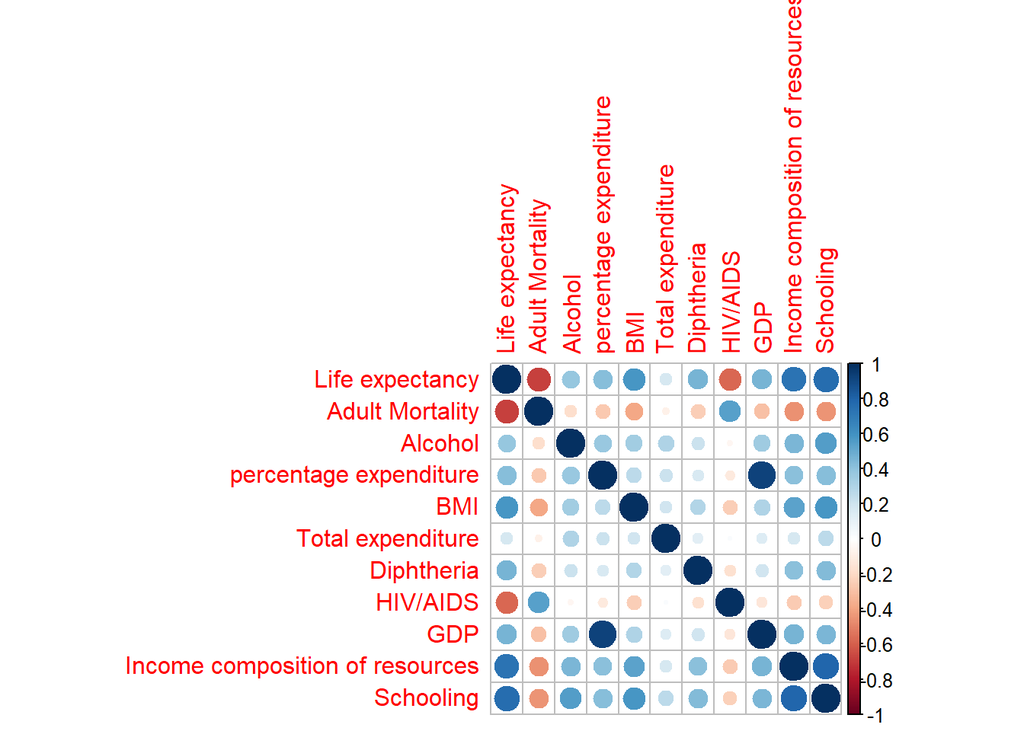

```r
corrplot(cor(data %>% select(`Life expectancy`, `Adult Mortality`, Alcohol,
                    `percentage expenditure`, BMI, `Total expenditure`,
                    Diphtheria, `HIV/AIDS`, GDP, `Income composition of resources`,
                    Schooling), method = "pearson", use = "pairwise.complete.obs")) # deals with na values
```

# One hot encode status rozvinutosti krajiny pre klasifikáciu

```r
data %<>%
  mutate(status_oh = if_else(Status=='Developed', "1", "0")) %>%
  relocate(status_oh)
```

# Priemerné hodnoty pre jednotlivé stĺpce, ktoré budeme používať pri pravdepodobnostných výpočtoch

```r
perc_mean <- mean(data$`percentage expenditure`)
GDP_mean <-  mean(data$GDP)
Schooling_mean <- mean(data$Schooling)
Adult_Mortality_mean <- mean(data$`Adult Mortality`)
Alcohol_mean <- mean(data$Alcohol)
life_expectancy_mean <- mean(data$`Life expectancy`)
status_oh_mean <- mean(data$status_oh)

# printing mean values
print(perc_mean)
```

```
## [1] 940.6717
```

```r
print(GDP_mean)
```

```
## [1] 7599.64
```

```r
print(Schooling_mean)
```

```
## [1] 12.11925
```

```r
print(Adult_Mortality_mean)
```

```
## [1] 161.6393
```

```r
print(Alcohol_mean)
```

```
## [1] 4.622347
```

```r
print(life_expectancy_mean)
```

```
## [1] 69.32173
```

# One hot stlpec pre Schooling podľa jej mean hodnoty

```r
data %<>%
  mutate(schooling_oh = if_else(Schooling > Schooling_mean, "1", "0")) %>%
  relocate(schooling_oh)
```

# One hot stlpec pre GDP podľa jej mean hodnoty

```r
data %<>%
  mutate(gdp_oh = if_else(GDP > GDP_mean, "1", "0")) %>%
  relocate(gdp_oh)
```

# One hot stlpec pre Adult Mortality podľa jej mean hodnoty

```r
data %<>%
  mutate(adult_mortality_oh = if_else(`Adult Mortality` > Adult_Mortality_mean, "1", "0")) %>%
  relocate(adult_mortality_oh)
```

# One hot stlpec pre Alcohol podľa jej mean hodnoty

```r
data %<>%
  mutate(alcohol_oh = if_else(Alcohol > Alcohol_mean, "1", "0")) %>%
  relocate(alcohol_oh)
```

# One hot stlpec pre percentage expenditure podľa jej mean hodnoty

```r
data %<>%
  mutate(percentage_expenditure_oh = if_else(`percentage expenditure` > perc_mean, "1", "0")) %>%
  relocate(percentage_expenditure_oh)
```

# One hot stlpec pre Life expectancy podľa jej mean hodnoty

```r
data %<>%
  mutate(life_expectancy_oh = if_else(`Life expectancy` > life_expectancy_mean, "1", "0")) %>%
  relocate(life_expectancy_oh)

data %<>%
  select(life_expectancy_oh, percentage_expenditure_oh, alcohol_oh, adult_mortality_oh, gdp_oh, schooling_oh, status_oh)
```

# Vytvorenie základnej tabuľky pravdivostných distribúcií pre one hot encoded stĺpce

```r
probTable <- data %>%
  summarise(
    p_0_gdp = sum(gdp_oh=="0")/length(gdp_oh),
    p_1_gdp = 1 - sum(gdp_oh=="0")/length(gdp_oh),
    p_0_schooling = sum(schooling_oh=="0")/length(schooling_oh),
    p_1_schooling = 1 - sum(schooling_oh=="0")/length(schooling_oh),
    p_0_alcohol = sum(alcohol_oh=="0")/length(alcohol_oh),
    p_1_alcohol = 1 - sum(alcohol_oh=="0")/length(alcohol_oh),
    p_0_adult_mortality = sum(adult_mortality_oh=="0")/length(adult_mortality_oh),
    p_1_adult_mortality = 1 - sum(adult_mortality_oh=="0")/length(adult_mortality_oh),
    p_0_percentage_expenditure = sum(percentage_expenditure_oh=="0")/length(percentage_expenditure_oh),
    p_1_percentage_expenditure = 1 - sum(percentage_expenditure_oh=="0")/length(percentage_expenditure_oh),
    p_0_life_expectancy = sum(life_expectancy_oh=="0")/length(life_expectancy_oh),
    p_1_life_expectancy = 1 - sum(life_expectancy_oh=="0")/length(life_expectancy_oh),
    p_0_status_oh = sum(status_oh=="0")/length(status_oh),
    p_1_status_oh = 1 - sum(status_oh=="0")/length(status_oh)
  )

# Converting probability table to matrix
probMatrix <- matrix(c(probTable$p_0_gdp, probTable$p_1_gdp,
                                probTable$p_0_schooling, probTable$p_1_schooling,
                                probTable$p_0_alcohol, probTable$p_1_alcohol,
                                probTable$p_0_adult_mortality, probTable$p_1_adult_mortality,
                                probTable$p_0_percentage_expenditure, probTable$p_1_percentage_expenditure,
                                probTable$p_0_life_expectancy, probTable$p_1_life_expectancy,
                                probTable$p_0_status_oh, probTable$p_1_status_oh),
                              nrow = 7, byrow = TRUE)

# Set column and row names of matrix
colnames(probMatrix) <- c("0", "1")
rownames(probMatrix) <- c("gdp_oh", "schooling_oh", "alcohol_oh", "adult_mortality_oh", "percentage_expenditure_oh", "life_expectancy_oh", "status_oh")

print(probMatrix)
```

```
##                                   0         1
## gdp_oh                    0.7840070 0.2159930
## schooling_oh              0.4671882 0.5328118
## alcohol_oh                0.5619296 0.4380704
## adult_mortality_oh        0.5910474 0.4089526
## percentage_expenditure_oh 0.8122555 0.1877445
## life_expectancy_oh        0.4137332 0.5862668
## status_oh                 0.8174707 0.1825293
```

# Bayesian sieť s 7 premennými a 10 vzťahovými závislosťami-hranami

```r
#vytvorenie sieti bolo inšpirované zdrojom:
#https://bookdown.org/robertness/causalml/docs/tutorial-probabilistic-modeling-with-bayesian-networks-and-bnlearn.html
#uncomment following lines if you don't have the package installed, if it is no longer available in CRAN - we zipped it
#r = getOption("repos")
#r["CRAN"] = "http://cran.us.r-project.org"
#options(repos = r)

#install.packages("BiocManager")
#BiocManager::install("Rgraphviz")

library(bnlearn)
library(Rgraphviz)

# Bayesian network structure with 7 nodes

required_variables <- c("status_oh", "life_expectancy_oh", "gdp_oh", "schooling_oh", "percentage_expenditure_oh", "adult_mortality_oh", "alcohol_oh")
data <- data[, required_variables]

bn <- empty.graph(nodes = c("gdp_oh", "schooling_oh", "alcohol_oh", "adult_mortality_oh",
                            "percentage_expenditure_oh", "life_expectancy_oh", "status_oh"))


# matrix pre nastavenie hran
arc.set <- matrix(c("gdp_oh", "percentage_expenditure_oh",
                    "schooling_oh", "gdp_oh",
                    "schooling_oh", "alcohol_oh",
                    "schooling_oh", "status_oh",
                    "alcohol_oh", "status_oh",
                    "alcohol_oh", "adult_mortality_oh",
                    "adult_mortality_oh", "status_oh",
                    "percentage_expenditure_oh", "adult_mortality_oh",
                    "percentage_expenditure_oh", "life_expectancy_oh",
                    "life_expectancy_oh", "status_oh"), ncol = 2, byrow = TRUE, dimnames = list(NULL, c("from", "to")))

arcs(bn) <- arc.set
arcs(bn)
```

```
##       from                        to
##  [1,] "gdp_oh"                    "percentage_expenditure_oh"
##  [2,] "schooling_oh"              "gdp_oh"
##  [3,] "schooling_oh"              "alcohol_oh"
##  [4,] "schooling_oh"              "status_oh"
##  [5,] "alcohol_oh"                "status_oh"
##  [6,] "alcohol_oh"                "adult_mortality_oh"
##  [7,] "adult_mortality_oh"        "status_oh"
##  [8,] "percentage_expenditure_oh" "adult_mortality_oh"
##  [9,] "percentage_expenditure_oh" "life_expectancy_oh"
## [10,] "life_expectancy_oh"        "status_oh"
```

```r
bnlearn::nodes(bn)
```

```
## [1] "gdp_oh"                    "schooling_oh"
## [3] "alcohol_oh"                "adult_mortality_oh"
## [5] "percentage_expenditure_oh" "life_expectancy_oh"
## [7] "status_oh"
```

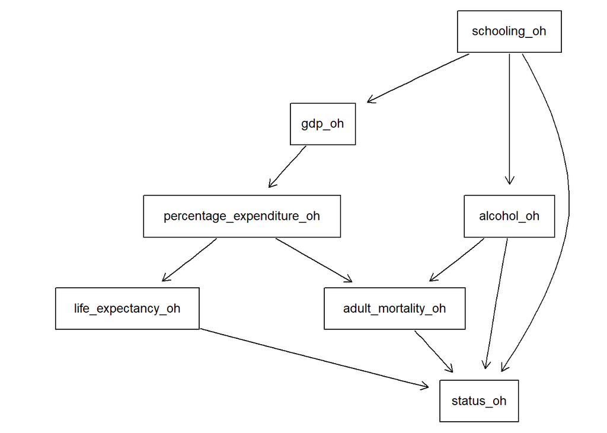

```r
graphviz.plot(bn)
```

```r
# fitnutie upravenych one hot encoded dat do bayesian siete, pretoze bnlearn nepodporuje numerické hodnoty
# vysledkom su pravdivostne tabulky na zaklade ktorych sme ratali nase pravdepodobnosti pre marketingove otazky

factor_data <- lapply(data[,], as.factor)

bn.fit <- bnlearn::bn.fit(bn, data = factor_data%>%data.frame())
bn.fit
```

```
##
##   Bayesian network parameters
##
##   Parameters of node gdp_oh (multinomial distribution)
##
## Conditional probability table:
##
##       schooling_oh
## gdp_oh          0          1
##      0 0.97767442 0.61419250
##      1 0.02232558 0.38580750
##
##   Parameters of node schooling_oh (multinomial distribution)
##
## Conditional probability table:
##          0         1
## 0.4671882 0.5328118
##
##   Parameters of node alcohol_oh (multinomial distribution)
##
## Conditional probability table:
##
##           schooling_oh
## alcohol_oh         0         1
##          0 0.8055814 0.3482871
##          1 0.1944186 0.6517129
##
##   Parameters of node adult_mortality_oh (multinomial distribution)
##
## Conditional probability table:
##
## , , percentage_expenditure_oh = 0
##
##                   alcohol_oh
## adult_mortality_oh          0          1
##                  0 0.48247078 0.57377049
##                  1 0.51752922 0.42622951
##
## , , percentage_expenditure_oh = 1
##
```

[output cut: 68 more lines]

```
##         1 0.00000000 0.58995138
##
## , , alcohol_oh = 0, adult_mortality_oh = 1, life_expectancy_oh = 1
##
##          schooling_oh
## status_oh          0          1
##         0 1.00000000 1.00000000
##         1 0.00000000 0.00000000
##
## , , alcohol_oh = 1, adult_mortality_oh = 1, life_expectancy_oh = 1
##
##          schooling_oh
## status_oh          0          1
##         0 0.82352941 0.71296296
##         1 0.17647059 0.28703704
```